# Modelling the distribution of biodiversity under global climate change

### Mask raster data

Mask subsets data to a region of interest. The mask is a raster layer with the same resolution and extent of the layer to be masked, but with values of NA in the areas to be masked and non-NA values in the areas to be kept.

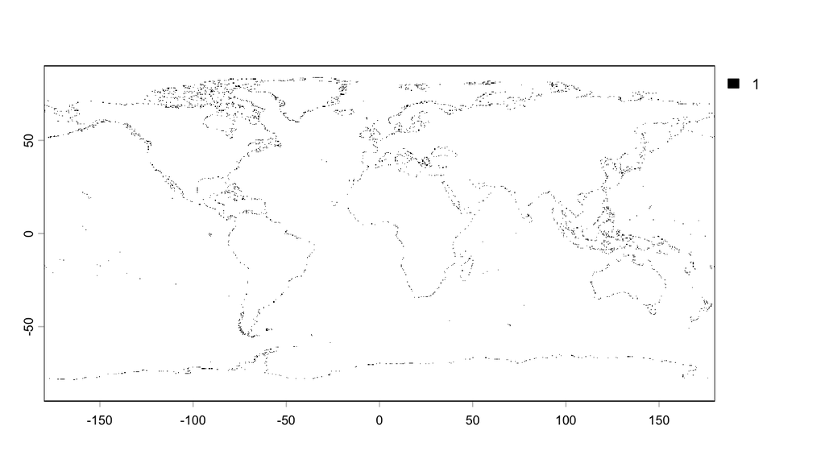

```r
# load a raster mask
coastalRegion <- rast("../Data/Raster data/CoastLine.tif")
# plot the raster mask
plot(coastalRegion, col = "black")
```

S2 // R as a Geographic Information System

biodiversityDS .

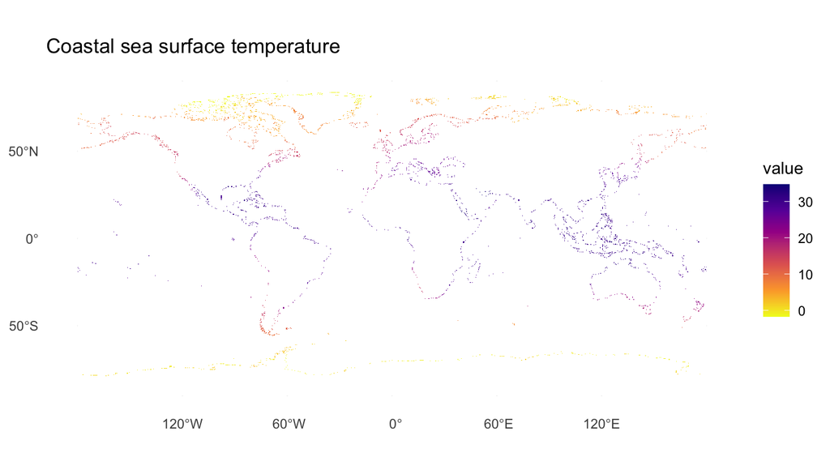

```r
# load the raster layer
seaSurfaceTemp <- rast("../Data/Raster data/Present Surface OceanTemperature LtMax.tif")
# mask with raster layer
coastalSeaSurfaceTemp <- mask(seaSurfaceTemp, coastalRegion)
# plot the masked layer
ggplot() + geom_spatraster(data = coastalSeaSurfaceTemp) + labs(title = "Coastal sea surface temperature") +
    scale_fill_viridis_c(option = "plasma", direction = -1, na.value = "white") + theme_minimal()
```

S2 // R as a Geographic Information System

biodiversityDS .

### Combine different rasters by resampling

To perform layer operation, data needs to be in the same resolution and extent. The **resample** function can be used to resample a raster layer to match the resolution and extent of another layer.

```r
# load raster layers
landCover <- rast("../Data/Raster data/LandCover GLCNMO.tif")
airTemperature <- rast("../Data/Raster data/AirTemperature Surface Ltmax.tif")
```

```r
# inspect resolution
res(landCover)
```

```
## [1] 0.004166667 0.004166667
```

```r
# inspect resolution
res(airTemperature)
```

```
## [1] 0.05 0.05
```

S2 // R as a Geographic Information System

biodiversityDS .

```r
# resample to layer to match extent and resolution
landCover <- resample(landCover, airTemperature)

# combine layers into one object
myLayers <- c(landCover, airTemperature)

myLayers
```

```
## class       : SpatRaster
## size        : 3600, 7200, 2  (nrow, ncol, nlyr)
## resolution  : 0.05, 0.05  (x, y)
## extent      : -180, 180, -90, 90  (xmin, xmax, ymin, ymax)
## coord. ref. : lon/lat WGS 84 (EPSG:4326)
## sources     : memory
##               AirTemperature Surface Ltmax.tif
## varnames    : AirTemperature Surface Ltmax
##               AirTemperature Surface Ltmax
## names       : LandCover GLCNMO, AirTemperature Surface Ltmax
## min values  :         2.134222,                     -8.32791
## max values  :        20.000000,                     40.04485
```

S2 // R as a Geographic Information System

biodiversityDS .

### Challenge 2.5

The main objective of this challenge is to **crop** a global SST layers to the **extent** of Western Africa

**Information**  
(min longitude: -30, max longitude: 22, min latitude: -37.5, max latitude: 37)  
**File to use**  
"Present Surface OceanTemperature LtMax.tif"  
**Packages to use**  
library  
rast  
ext  
crop  
plot

S2 // R as a Geographic Information System

## Algebra in raster data

biodiversityDS .

#### Change the values of a raster layer

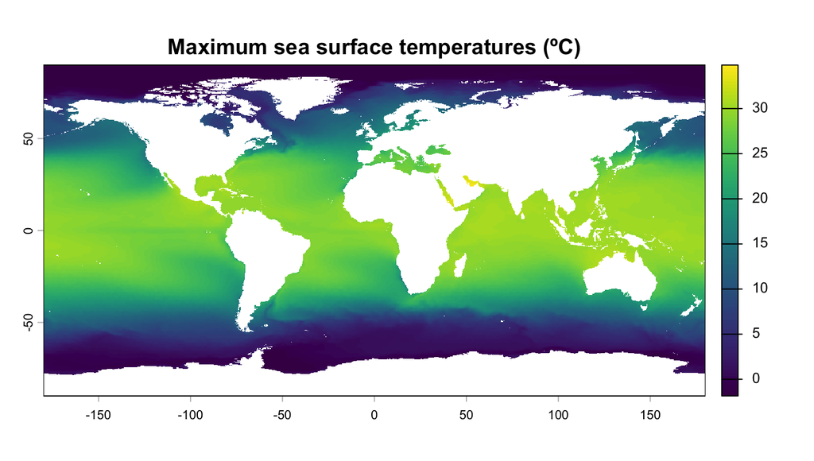

```r
# open a raster layer
seaSurfaceTemp <- rast("../Data/Raster data/Present Surface OceanTemperature LtMax.tif")
plot(seaSurfaceTemp, main = "Maximum sea surface temperatures (ºC)")
```

S2 // R as a Geographic Information System

## Algebra in raster data

biodiversityDS .

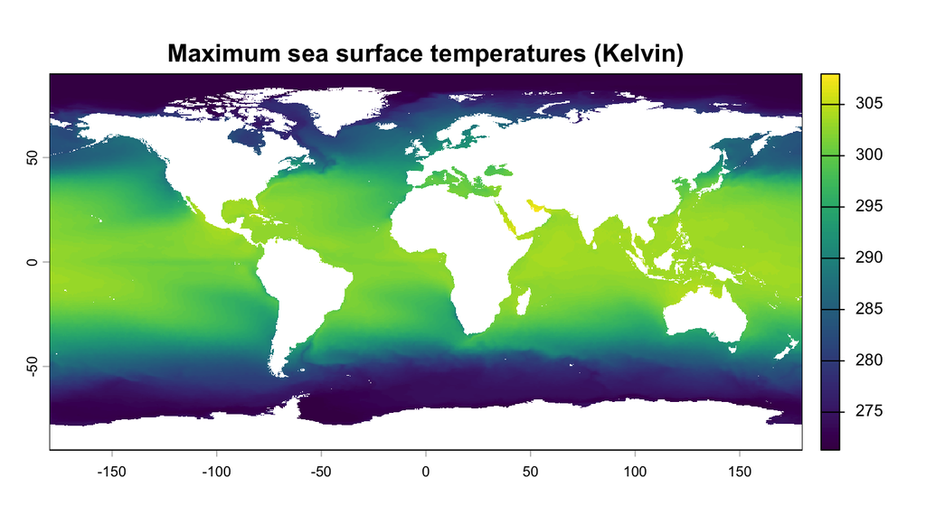

```r
# change the values of a raster layer by summing a constant value
seaSurfaceTempKelvin <- seaSurfaceTemp + 273.15
plot(seaSurfaceTempKelvin, main = "Maximum sea surface temperatures (Kelvin)")
```

S2 // R as a Geographic Information System

biodiversityDS .

#### Use algebra functions between raster layers

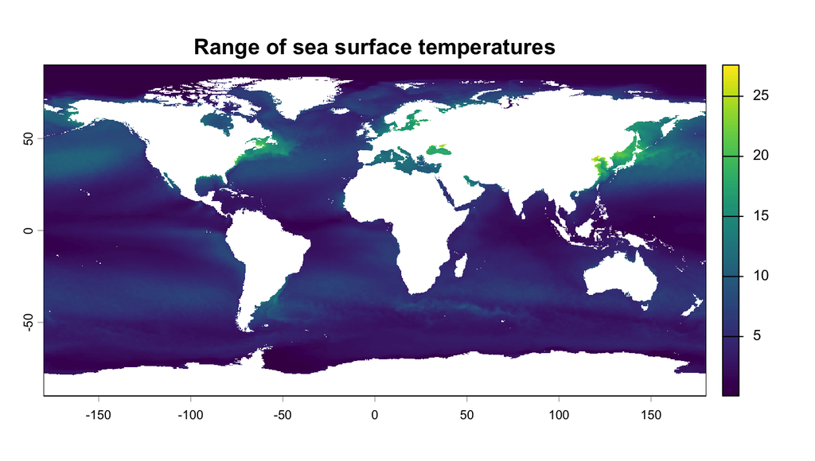

```r
# open two temperature layers of the minimum and maximum extremes
seaSurfaceTempMax <- rast("../Data/Raster data/Present Surface OceanTemperature LtMax.tif")
seaSurfaceTempMin <- rast("../Data/Raster data/Present Surface OceanTemperature LtMin.tif")
# determine the range of temperatures by simple a simple operation between layers
rangeSeaSurfaceTemp <- seaSurfaceTempMax - seaSurfaceTempMin
plot(rangeSeaSurfaceTemp, main = "Range of sea surface temperatures")
```

S2 // R as a Geographic Information System

biodiversityDS .

### Use algebra functions between raster layers

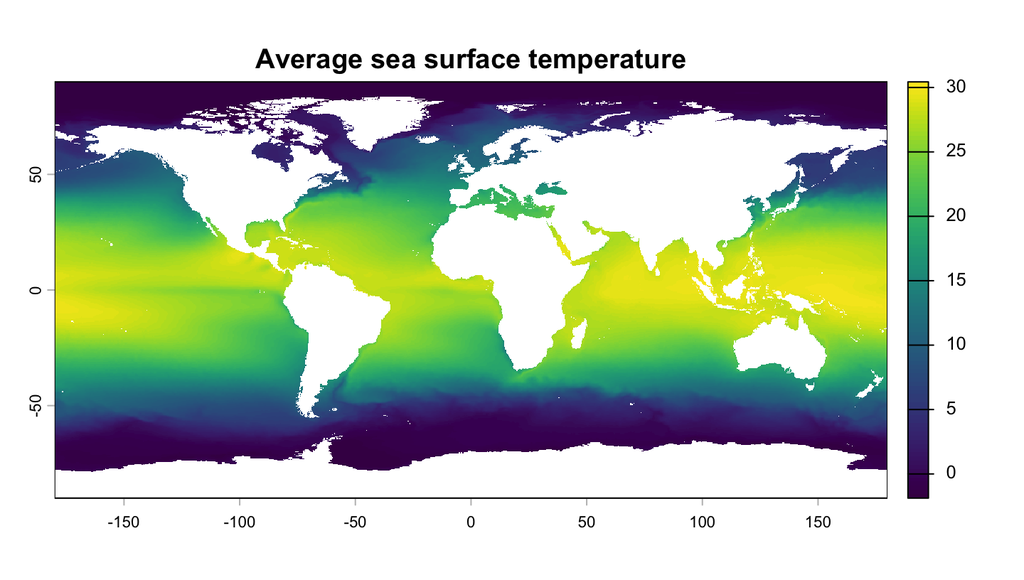

```r
# combine two raster layers and determine their mean
myFiles <- c("../Data/Raster data/Present Surface OceanTemperature LtMax.tif", "../Data/Raster data/Present Surface OceanTemperature LtMin.tif")
seaSurfaceTemp <- rast(myFiles)
# determine the average temperature between layers using the app function
averageSeaSurfaceTemp <- app(seaSurfaceTemp, fun = mean)
plot(averageSeaSurfaceTemp, main = "Average sea surface temperature")
```

S2 // R as a Geographic Information System

biodiversityDS .

### Challenge 2.6

The main objective of this challenge is to **map** the global mean sea surface temperatures using the **app** function of terra package.

**Packages, files and functions to accomplish the challenge:**

**Files to use**  
"Present Surface OceanTemperature LtMax.tif"  
"Present Surface OceanTemperature LtMin.tif"  
**Functions to use**  
library  
rast  
app  
plot

S2 // R as a Geographic Information System

biodiversityDS .

### Challenge 2.7

The main objective of this challenge is to **map** the average sea surface temperatures of the Mediterranean Sea

**Packages, data and functions to accomplish the challenge:**

**Information**  
(min longitude: -15, max longitude: 45, min latitude: 30, max latitude: 47.5)  
**Files to use**  
"Present Surface OceanTemperature LtMax.tif"  
"Present Surface OceanTemperature LtMin.tif"  
**Functions to use**  
library  
rast  
ext  
crop  
app  
plot

S2 // R as a Geographic Information System

## Classify (or reclassify) raster values

biodiversityDS .

The classify function reclassifies raster values based on the argument rcl, a three-column matrix “from-to-becomes”

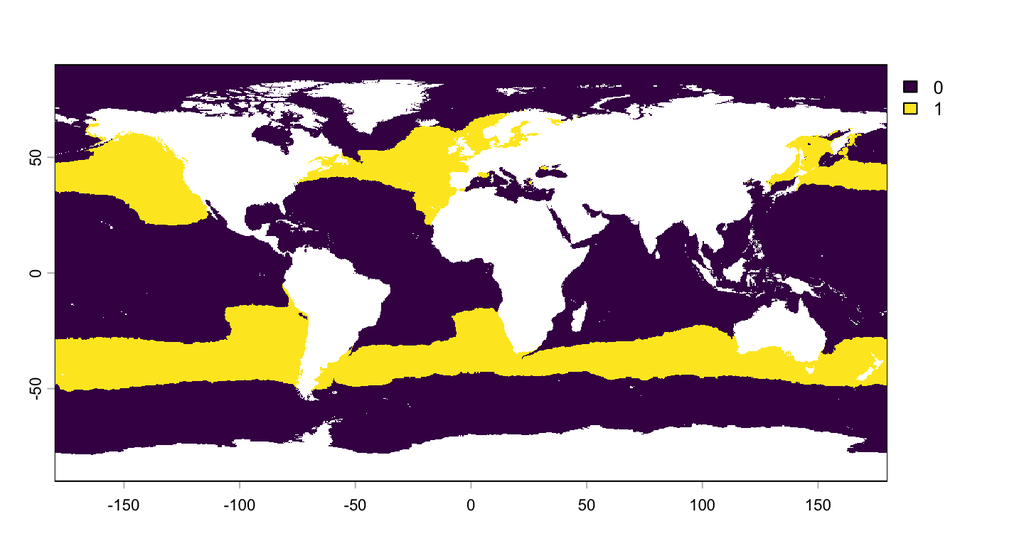

```r
# open a raster layer
temperatureLayer <- rast("../Data/Raster data/Present Surface OceanTemperature LtMax.tif")
# from-to-becomes matrix
rclmat <- data.frame(from = c(-Inf, 12, 25), to = c(12, 25, Inf), becomes = c(0, 1, 0))
temperatureLayerReclass <- classify(temperatureLayer, rclmat)
plot(temperatureLayerReclass)
```

S2 // R as a Geographic Information System

biodiversityDS .

### Challenge 2.8

The main objective of this challenge is to map the distribution of a species with an thermal tolerance between 12 and 25 degrees using the classify function.

**Packages, files and functions to accomplish the challenge:**

**Files to use**  
"Present Surface OceanTemperature LtMax.tif"  
**Functions to use**  
library  
rast  
data.frame  
classify  
plot

S2 // R as a Geographic Information System

## Correlation between predictors

biodiversityDS .

Correlation between predictors is important to avoid multicollinearity.

```r
# create a vector with the path to the raster layers
myFiles <- c("../Data/Raster data/Present Surface OceanTemperature LtMax.tif", "../Data/Raster data/Present Benthic OceanTemperature LtMax.tif",
    "../Data/Raster data/Present Surface Nitrate Mean.tif", "../Data/Raster data/Bathymetry.tif")
# combining the raster layers
environmentLayers <- rast(myFiles)
# change name of layers for simplicity
names(environmentLayers) <- c("Surface temperature", "Benthic temperature", "Nitrate", "Bathymetry")
```

S2 // R as a Geographic Information System

biodiversityDS .

The **getCorrPlot** function from the **biodiversityDS** package can be used to calculate and plot the correlation between raster layers.

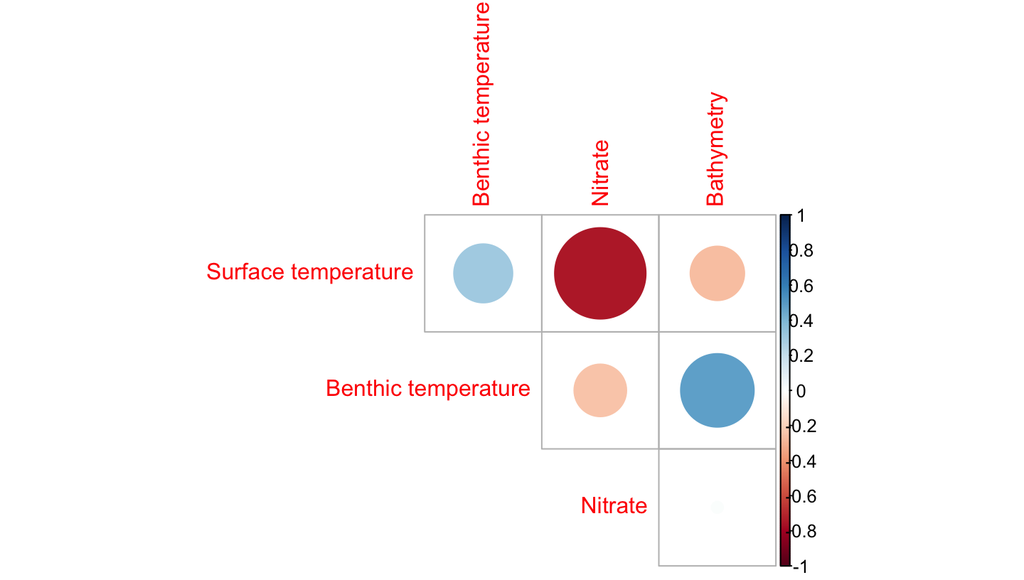

```r
# get correlation between pairs of layers
correlations <- getCorrPlot(environmentLayers)
```

S2 // R as a Geographic Information System

biodiversityDS .

The **vifstep** function from the **usdm** package can be used to calculate the variance inflation factor (VIF) and remove highly correlated predictors.

```r
library(usdm)
# calculate VIF and remove highly correlated predictors
vifstep(environmentLayers, th = 10)
```

```
## No variable from the 4 input variables has collinearity problem.
##
## The linear correlation coefficients ranges between:
## min correlation ( Bathymetry ~ Nitrate ):  0.005259897
## max correlation ( Nitrate ~ Surface temperature ):  -0.7427354
##
## ---------- VIFs of the remained variables --------
##             Variables      VIF
## 1 Surface temperature 3.360513
## 2 Benthic temperature 1.844296
## 3             Nitrate 2.524685
## 4          Bathymetry 1.941453
```

S2 // R as a Geographic Information System

biodiversityDS .

### Challenge 2.9

The main objective of this challenge is to assess the **correlation between predictors** within the Mediterranean Sea.

**Packages, files and functions to accomplish the challenge:**

**Files to use**  
"Present Benthic OceanTemperature LtMax.tif"  
"Present Benthic OceanTemperature LtMin.tif"  
"Present Benthic Salinity Mean.tif"  
"Present Benthic TotalPrimaryProductionPhyto Mean"  
**Functions to use**  
library  
rast  
ext  
crop  
getCorrPlot  
vifstep

S2 // R as a Geographic Information System